# Simulation Project - Pierson Wodarz

STAT 420, Summer 2020, Pierson Wodarz (wodarz2)

6/24/2020

# Overview

In this document we conduct simulation studies which explore three statistical concepts:

- Study 1: Significance of Regression
- Study 2: Using RMSE for Selection
- Study 3: Power

We explore these statistical concepts by simulating data in R and examining the results.

# Simulation Study 1: Significance of Regression

## Introduction

In this simulation study we will investigate the significance of regression test by comparing a model with a significant linear relationship to a model with a non-significant relationship. We will simulate from two different models:

1. The **“significant”** model: $Y_i = \beta_0 + \beta_1 x_{i1} + \beta_2 x_{i2} + \beta_3 x_{i3} + \epsilon_i$

   where $\epsilon_i \sim N(0, \sigma^2)$ and $\beta_0 = 3$, $\beta_1 = 1$, $\beta_2 = 1$, $\beta_3 = 1$.
2. The **“non-significant”** model: $Y_i = \beta_0 + \beta_1 x_{i1} + \beta_2 x_{i2} + \beta_3 x_{i3} + \epsilon_i$

   where $\epsilon_i \sim N(0, \sigma^2)$ and $\beta_0 = 3$, $\beta_1 = 0$, $\beta_2 = 0$, $\beta_3 = 0$.

For both, we will consider a sample size of $25$ and three possible levels of noise. That is, three values of $\sigma$.

- $n = 25$
- $\sigma \in (1, 5, 10)$

For each model and $\sigma$ combination we will generate $2000$ simulations. Additionally, we will focus on the following values from each simulation:

- The **$F$ statistic** for the significance of regression test.
- The **p-value** for the significance of regression test
- **$R^2$**

The goal is to identify how these values vary due to different values of $\sigma$ and between simulated data with a signficant linear relationship and data without a signficant linear relationship.

## Methods

We use the data in `study_1.csv` for the values of the predictors ($x_{1},x_{2},x_{3}$).

```r
library(readr)
study_1 = read_csv("study_1.csv")
x0 = rep(1, times = length(study_1$x1))
x1 = study_1$x1
x2 = study_1$x2
x3 = study_1$x3
```

We set the $\beta$ values for our significant and non-significant models as well as our other given values for sample size, sigma, and number of simulations.

```r
models = data.frame(sig_model = c(3,1,1,1), non_sig_model = c(3,0,0,0)) # set beta values
n = 25 # setting sample size
n_sim = 2000 # setting number of simulations
sigma = c(1, 5, 10) # storing sigma
```

We write a function to simulate the data and store the resulting values for the different models and values of sigma.

```r
sim_mlr = function(model, s){
   f_statistic = rep(0, times = n_sim)
   p_value = rep(0, times = n_sim)
   r_2 = rep(0, times = n_sim)
   for (i in 1 : n_sim){
      eps = rnorm(n, mean = 0, sd = s)
      y = model[1] * x0 + model[2] * x1 + model[3] * x2 + model[4] * x3 + eps
      fit = lm(y ~ x1 + x2 + x3)
      f_statistic[i] = summary(fit)$fstatistic[1]
      p_value[i] = pf(f_statistic[i], df1 = length(coef(fit)) - 1, df2 = n - length(coef(fit)), lower.tail = FALSE)
      r_2[i] = summary(fit)$r.squared
   }
   data.frame(f_statistic = f_statistic, p_value = p_value, r_2 = r_2)
}

sig_model_s1 = sim_mlr(models[,"sig_model"], sigma[1])
sig_model_s5 = sim_mlr(models[,"sig_model"], sigma[2])
sig_model_s10 = sim_mlr(models[,"sig_model"], sigma[3])
non_sig_model_s1 = sim_mlr(models[,"non_sig_model"], sigma[1])
non_sig_model_s5 = sim_mlr(models[,"non_sig_model"], sigma[2])
non_sig_model_s10 = sim_mlr(models[,"non_sig_model"], sigma[3])
```

## Results

**$F$ Statistic**

Mean value:

|  | Significant Model | Non-Significant Model |
| --- | --- | --- |
| $\sigma \ = \ 1$ | 41.1749 | 1.1257 |
| $\sigma \ = \ 5$ | 2.6968 | 1.0936 |
| $\sigma \ = \ 10$ | 1.4622 | 1.073 |

Distribution:

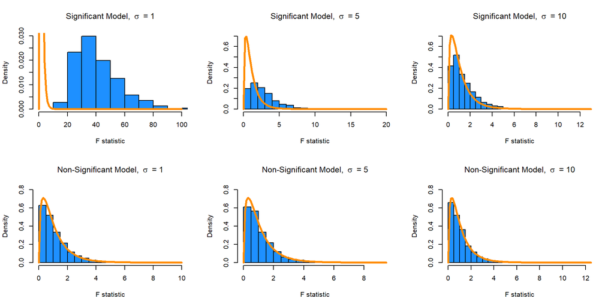

- Note: The $F_{p - 1, n - p}$ distribution has been overlayed onto these graphs as the orange curve.

**p-value**

Mean value:

[output not shown]

Distribution:

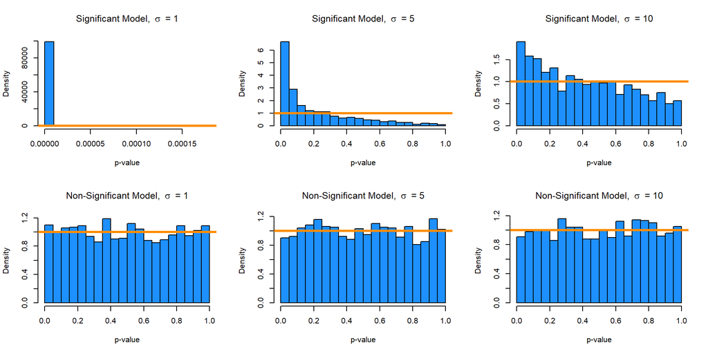

- Note: The distribution of the p-value under the null-hypothesis has been overlayed onto these graphs as the orange curve. Under the null hypothesis, this is a uniform distribution.

**$R^2$**

Mean Value:

|  | Significant Model | Non-Significant Model |
| --- | --- | --- |
| $\sigma \ = \ 1$ | 0.8399 | 0.1268 |
| $\sigma \ = \ 5$ | 0.2514 | 0.1243 |
| $\sigma \ = \ 10$ | 0.1569 | 0.1224 |

Distribution:

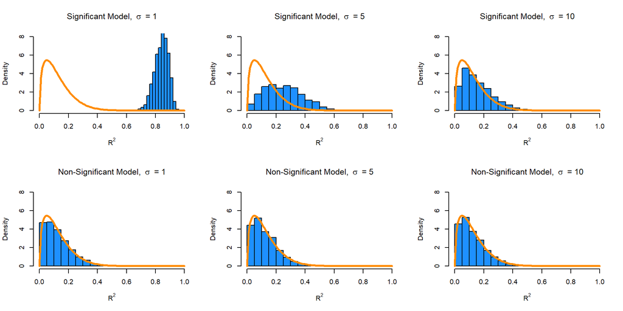

- Note: The distribution of $R^2$ under the null hypothesis has been overlayed onto these graphs as the orange curve. Under the null hypothesis this distrubution is $R^2 \sim Beta(\frac{p - 1}{2}, \frac{n - p}{2})$

## Discussion

First, we note the true distribution for each of the values *under the null hypothesis*. Specifically, the $F$ Statistic follows an $F_{p - 1, n - p}$ distribution, the p-value follows a uniform distribution, and $R^2 \sim Beta(\frac{p - 1}{2}, \frac{n - p}{2})$.

We see that, for each of the **non-significant models**, the distributions for each of the values closely follows the distribution we would expect under the null hypothesis. This makes sense, as there is no signficant linear relationship so we would expect the distributions to follow the distributions for the null hypothesis. We don’t see a significant change between $\sigma$ values for the corresponding $F$ statistic, p-value, or $R^2$ distributions.

Additionally, we note that for the **significant models** the distributions generally deviate from those we would expect to see under the null hypothesis. However, as the noise ($\sigma$) is increased, we see that the distribution of the significant model is much closer to that of the distribution under the null hypothesis. So for the significant model with $\sigma$ = 1 the value distributions deviate more from the null hypothesis distributions than those of $\sigma$ = 10 (which is more similar to the null hypothesis distributions because there is more noise and randomness).

We see that, as $\sigma$ increases, the mean $F$ statistic and $R^2$ decreases. We would expect this as the noiser the signal becomes, the less portion of the variance can be explained by the regression (more is explained by noise). The inverse is true of the p-value (as $\sigma$ increases, the mean p-value increases), for a similar reason. We note that this effect is much larger for the significant model than the non-significant model, which is expected as the significant model is simulated from an actual significant linear relationship.

# Simulation Study 2: Using RMSE for Selection

## Introduction

For multiple linear regression we can use Test RMSE to select the “best” model. In this simulation study, we will investigate how well this procedure works.

We will simulate from the model: $Y_i = \beta_0 + \beta_1 x_{i1} + \beta_2 x_{i2} + \beta_3 x_{i3} + \beta_4 x_{i4} + \beta_5 x_{i5} + \beta_6 x_{i6} + \epsilon_i$

- Where $\epsilon_i \sim N(0, \sigma^2)$ and $\beta_0 = 0$, $\beta_1 = 3$, $\beta_2 = -4$, $\beta_3 = 1.6$, $\beta_4 = -1.1$, $\beta_5 = 0.7$, $\beta_6 = 0.5$.

We will consider a sample size of $500$ and three possible levels of noise. That is, three values of $\sigma$.

- $n = 500$
- $\sigma \in (1, 2, 4)$

For each simulation we will randomly split the data into train and test sets of equal sizes (250 observations for training, 250 observations for testing).

Additionally, for each simulation, we will fit nine models, with the forms:

- Model 1: `y ~ x1`
- Model 2: `y ~ x1 + x2`
- Model 3: `y ~ x1 + x2 + x3`
- Model 4: `y ~ x1 + x2 + x3 + x4`
- Model 5: `y ~ x1 + x2 + x3 + x4 + x5`
- Model 6: `y ~ x1 + x2 + x3 + x4 + x5 + x6` (the correct form of the model as noted above)
- Model 7: `y ~ x1 + x2 + x3 + x4 + x5 + x6 + x7`
- Model 8: `y ~ x1 + x2 + x3 + x4 + x5 + x6 + x7 + x8`
- Model 9: `y ~ x1 + x2 + x3 + x4 + x5 + x6 + x7 + x8 + x9`

And for each of these models we will calculate the Train and Test RMSE.

$$\text{RMSE}(\text{model, data}) = \sqrt{\frac{1}{n} \sum_{i = 1}^{n}(y_i - \hat{y}_i)^2}$$

We will perform this process for $1000$ simulations for each of the $3$ values of $\sigma$.

We will observe how, for each value of $\sigma$, the average Train RMSE and average Test RMSE changes as a function of model size. Additionally, we will observe how frequently each model was selected as the “best” model based on the Test RMSE.

## Methods

```r
study_2 = read_csv("study_2.csv")
```

We set the $\beta$ values, sigma, sample size, and number of simulations.

```r
beta_0 = 0
beta_1 = 3
beta_2 = -4
beta_3 = 1.6
beta_4 = -1.1
beta_5 = 0.7
beta_6 = 0.5

n = 500 # sample size
n_sim = 1000 # number of simulations
sigma = c(1, 2, 4) # different levels of noise
```

We write a function to simulate the data and store the resulting values for the different models and values of sigma.

```r
sim_RMSE = function(s){

   model_train_RMSE = matrix(0, nrow = 9, ncol = n_sim)
   model_test_RMSE = matrix(0, nrow = 9, ncol = n_sim)

   for (i in 1 : n_sim){
      eps = rnorm(n, mean = 0, sd = s)
      study_2$y = beta_0 +
         beta_1 * study_2$x1 +
         beta_2 * study_2$x2 +
         beta_3 * study_2$x3 +
         beta_4 * study_2$x4 +
         beta_5 * study_2$x5 +
         beta_6 * study_2$x6 +
         eps

      index = seq(1, nrow(study_2), 1)
      study_2_trn_idx = sample(1 : nrow(study_2), n / 2)
      study_2_tst_idx = setdiff(index, study_2_trn_idx)

      study_2_trn = study_2[study_2_trn_idx, ]
      study_2_tst = study_2[study_2_tst_idx, ]

      model_fit = list(lm(y ~ x1, data = study_2_trn),
                             lm(y ~ x1 + x2, data = study_2_trn),
                             lm(y ~ x1 + x2 + x3, data = study_2_trn),
                             lm(y ~ x1 + x2 + x3 + x4, data = study_2_trn),
                             lm(y ~ x1 + x2 + x3 + x4 + x5, data = study_2_trn),
                             lm(y ~ x1 + x2 + x3 + x4 + x5 + x6, data = study_2_trn),
                             lm(y ~ x1 + x2 + x3 + x4 + x5 + x6 + x7, data = study_2_trn),
                             lm(y ~ x1 + x2 + x3 + x4 + x5 + x6 + x7 + x8, data = study_2_trn),
                             lm(y ~ x1 + x2 + x3 + x4 + x5 + x6 + x7 + x8 + x9, data = study_2_trn)
      )

      for(m in 1 : 9){
         model_train_RMSE[m, i] = sqrt((1 / nrow(study_2_trn)) * sum((study_2_trn$y - predict(model_fit[[m]], newdata = study_2_trn)) ^ 2))
      }
      for(m in 1 : 9){
         model_test_RMSE[m, i] = sqrt((1 / nrow(study_2_tst)) * sum((study_2_tst$y - predict(model_fit[[m]], newdata = study_2_tst)) ^ 2))
      }

   }

   list(model_train_RMSE = t(model_train_RMSE), model_test_RMSE = t(model_test_RMSE))
}

model_s1 = sim_RMSE(sigma[1])
model_s2 = sim_RMSE(sigma[2])
model_s4 = sim_RMSE(sigma[3])
```

With the simulated RMSE results above, we write code to identify which model was chosen during each simulation

```r
model_count_s1 = rep(0, 9)
model_count_s2 = rep(0, 9)
model_count_s4 = rep(0, 9)

for (r in 1 : n_sim){
   idx = which(model_s1[["model_test_RMSE"]][r,] == min(model_s1[["model_test_RMSE"]][r,]))
   jdx = which(model_s2[["model_test_RMSE"]][r,] == min(model_s2[["model_test_RMSE"]][r,]))
   kdx = which(model_s4[["model_test_RMSE"]][r,] == min(model_s4[["model_test_RMSE"]][r,]))
   model_count_s1[idx] = model_count_s1[idx] + 1
   model_count_s2[jdx] = model_count_s2[jdx] + 1
   model_count_s4[kdx] = model_count_s4[kdx] + 1
}

chosen_count = rbind(model_count_s1, model_count_s2, model_count_s4)
```

## Results

**Mean RMSE (graph)**

[figure not shown]

**Mean RMSE (table)**

[output not shown]

**Chosen Model**

Number of times each model was chosen based on lowest Test RMSE:

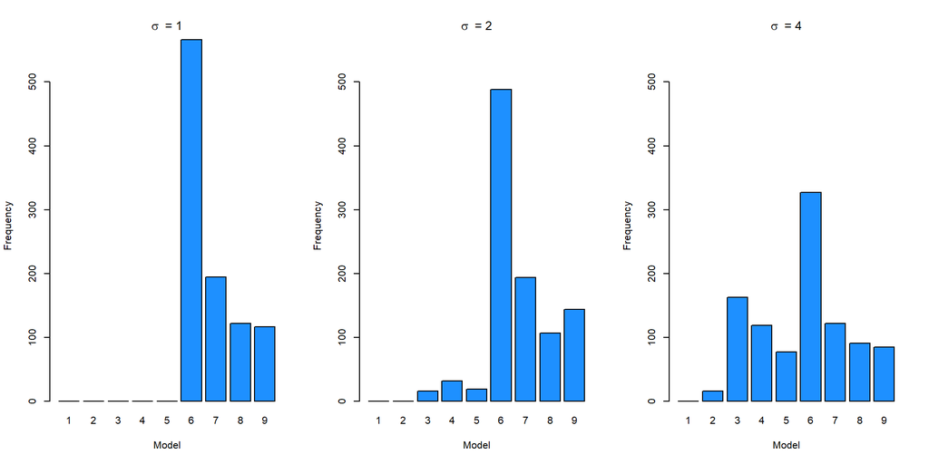

|  | Model 1 | Model 2 | Model 3 | Model 4 | Model 5 | Model 6 | Model 7 | Model 8 | Model 9 |
| --- | --- | --- | --- | --- | --- | --- | --- | --- | --- |
| σ = 1 | 0 | 0 | 0 | 0 | 0 | 566 | 195 | 122 | 117 |
| σ = 2 | 0 | 0 | 16 | 32 | 19 | 488 | 194 | 107 | 144 |
| σ = 4 | 0 | 16 | 163 | 119 | 77 | 327 | 122 | 91 | 85 |

## Discussion

We note that Model 6 (the correct form of the true model) has the lowest average Test RMSE for all values of $\sigma$. Additionally, we see that Model 6 is selected as the best model most often for all values of $\sigma$. These results were expected as Model 6 is the correct form of the model and therefore we would expect its Test RMSE to be, on average, the lowest and for it to be chosen most often.

Importantly, this method *did not always select the correct model*. This method selected the correct model on average, and most often, but it did not select the correct model in every simulation due to the level of noise that was present.

The level of noise ($\sigma$) did have an effect on the results. Namely, as the noise increased we see that the Model 6, while still selected as the best model most frequently, is selected less often, and an incorrect model is selected as the best model more frequently. Additionally we note that the range of Test RMSEs across models decreases as the noise increases. The inverse phenomemon is also observable when comparing the difference between the Test RMSE and Train RMSE for the same model: as the noise increases, the difference between the Test RMSE and Train RMSE increased.

Additionally, we selected a wider variety of incorrect models as the best model when the noise increased. For $\sigma$ = 1 we observed a selection of models 6 - 9 while for $\sigma$ = 4 we observed a selection of models 2 - 9.

# Simulation Study 3: Power

## Introduction

In this simulation study we will investigate the power of the significance of regression test for simple linear regression.

$$H_0: \beta_{1} = 0 \ \text{vs} \ H_1: \beta_{1} \neq 0$$

Power is the probability of rejecting the null hypothesis when the null is not true, that is, the alternative is true and $\beta_{1}$ is non-zero.

$$\text{Power} = P[\text{Reject } H_0 \mid H_1 \text{ True}]$$

Stated differently, power is the probability that a signal of a particular strength will be detected. Many things affect the power of a test. In this study, we will investigate the following:

- Sample Size, $n$
- Signal Strength, $\beta_1$
- Noise Level, $\sigma$

To do so we will simulate from the model: $Y_i = \beta_0 + \beta_1 x_i + \epsilon_i$

- where $\epsilon_i \sim N(0, \sigma^2)$.

For simplicity, we will let $\beta_0 = 0$, thus $\beta_1$ is essentially controlling the amount of “signal.” We will then consider different signals, noises, and sample sizes:

- $\beta_1 \in (-2, -1.9, -1.8, \ldots, -0.1, 0, 0.1, 0.2, 0.3, \ldots 1.9, 2)$
- $\sigma \in (1, 2, 4)$
- $n \in (10, 20, 30)$

We will hold the significance level constant at $\alpha = 0.05$.

For each possible $\beta_1$ and $\sigma$ combination, we will simulate from the true model $1000$ times. Each time, we will perform the significance of the regression test. To estimate the power with these simulations, and some $\alpha$, we use:

$$\hat{\text{Power}} = \hat{P}[\text{Reject } H_0 \mid H_1 \text{ True}] = \frac{\text{# Tests Rejected}}{\text{# Simulations}}$$

## Methods

We set the values for $\alpha$, $\beta$, $\sigma$, sample size and number of simulations.

```r
alpha = 0.05
beta_1 = seq(from = -2, to = 2, by = 0.1)
sigma = c(1, 2, 4)
sample_size = c(10, 20, 30)
n_sim = 1000
```

We write a function to loop over the values of $\beta$ and sample size and return the calculated p values for various values of $\sigma$.

```r
sim_sig_reg = function(s){
   power_val = matrix(0, nrow = length(sample_size), ncol = length(beta_1))
   pval = array(0, c(length(sample_size), length(beta_1), n_sim))
   for(i in 1 : length(sample_size)){
      n = sample_size[i]
      for(j in 1 : length(beta_1)){
         for (k in 1 : n_sim){
            b = beta_1[j]
            x_values = seq(0, 5, length = n)
            eps = rnorm(n, mean = 0, sd = s)
            y = x_values * b + eps
            fit = lm(y ~ x_values)
            pval[i, j, k] = summary(fit)$coef["x_values", "Pr(>|t|)"]
         }
         power_val[i, j] = sum(pval[i, j, ] < alpha) / n_sim
      }
   }
   power_val
}

power_vals_s1 = sim_sig_reg(sigma[1])
power_vals_s2 = sim_sig_reg(sigma[2])
power_vals_s4 = sim_sig_reg(sigma[3])
```

## Results

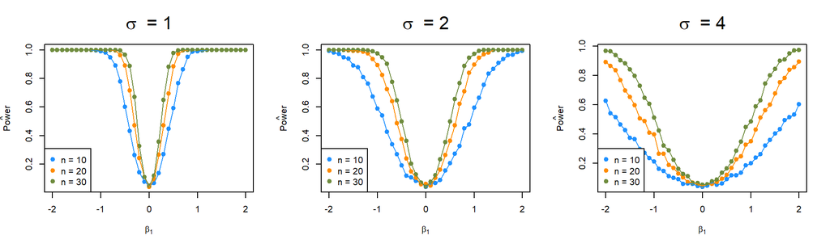

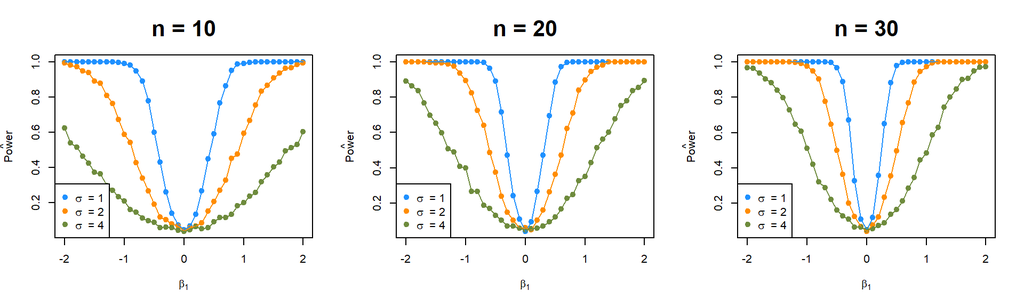

## Discussion

From the results, it is clear that $\beta_1$, $\sigma$ and $n$ all affect power.

Namely, as the true value of $\beta_1$ moves further from $0$, power increases. This is expected as our null hypothesis is $H_{0}: \beta_{1} = 0$ and therefore as the true value of $\beta_1$ grows closer to $0$ we would expect to fail to reject the null hypothesis more often. Specifically, as the confidence interval length should be similar for a constant $n$ and $\sigma$, $0$ will fall into the confidence interval more often the closer $\beta_1$ is to $0$. Essentially, we find that the further $\beta_1$ is from the null hypothesis, the easier the signal is to seperate from the noise ($\sigma$).

Similarly, as $n$ increases (holding $\sigma$ and $\beta_1$ constant), we find that power increases. A larger sample size reduces RSE and the length of our confidence intervals. That is to say, we can have greater confidence that the true value is within a specific range. This true value translates to the signal, and so on average we would expect to have more accurately identified the true value of the signal, which we see that we do with the higher power.

The inverse of the behavior for $\beta_1$ and $n$ is true for $\sigma$. Namely, we see that as $\sigma$ increases, the power decreases (for a constant $n$ and $\beta_1$). This follows by the definition of power and $\sigma$. In particular, by increasing $\sigma$ we are increasing the noise and therefore it becomes more difficult to identify the signal in the noise, which is the definition of power, so power decreases.

We can see that with $1000$ simulations, the results are converging to a smooth distribution curve, indicating that the number of simulations is sufficient for the purposes of determining the power.